# results

Jialiang

2023-03-27

## Preparation

### R setup

Load the packages we will be using in this document.

```r
## Load and install the R packages we might will be using.
pacman::p_load(sf, tidyverse, magrittr, data.table, hrbrthemes, zoo, GWmodel, spatialreg, spdep, plm, splm, pspatreg, zoo, chatgpt)
```

Some data wrangling work.

```r
# Replace the absolute path of the `cities_included.shp` file on your computer.
# Drag the file to terminal (command + space, then search `terminal` on spotlight) if you are in mac, the path will appear.
ct_shape <- st_read("/Users/jialiangchen/Documents/spmodeltoruism/shapefiles/china_second_level_admin_shape/cities_included.shp")
## Import more data.
## change the absolute path on your computer, same as above
ct_data <- read.csv("/Users/jialiangchen/Documents/spmodeltoruism/data/dataforR.csv")
## Perform a left join for our datasets.
ct_spdata_wide <- left_join(
  ct_shape %>% select(NL_NAME_2, geometry) %>% rename(城市shapefile = NL_NAME_2),
  ct_data,
  by = "城市shapefile"
)

## Reshape our data to long(tidy) form.
ct_spdata_long <- ct_spdata_wide %>%
  pivot_longer(
    cols = tarl_2011:grnld_2019,
    names_to = c(".value", "year"),
    names_pattern = "(.+)_(.+)"
  )

## Create average tourist expenditure variable in RMBs
ct_spdata_long %<>%
  mutate(
    tavexp =  (trev/tarl)*1000,
    dmavexp = (dmrev/dmarl)*1000
  )

## Some place has zero international arrival
## Avoid division by zero
ct_spdata_long %<>%
  mutate(
    inavexp = case_when(
     inarl > 0 ~  (inrev/inarl)*7*1000,
     inarl == 0 ~  0
    )
  )


## Create average tourist expenditure variable in RMBs## Convert the "human" variables from 10 thousands to thousands, just for consistency
ct_spdata_long %<>%
  mutate(emphotel = emphotel * 10,
         pop = pop * 10
  )

## linear interpolation to deal with missing values
ct_spdata_long %<>%
        mutate(across(c(tarl:inavexp), \(x) zoo::na.approx(x, rule = 2)))

## check if there are still NA left
sum(is.na(ct_spdata_long))
```

```
## [1] 0
```

```r
## set tell R it is a panel
ct_spdata_long <- pdata.frame(ct_spdata_long, index = c("城市shapefile", "year"))
## summarize the data
summary(ct_spdata_long)
```

```
##    城市shapefile      City                Lat             Long
##  三亚市   :   9   Length:2547        Min.   :18.26   Min.   : 84.9
##  三明市   :   9   Class :character   1st Qu.:27.83   1st Qu.:109.5
##  三门峡市 :   9   Mode  :character   Median :32.40   Median :114.3
##  上海|上海:   9                      Mean   :32.80   Mean   :113.9
##  上饶市   :   9                      3rd Qu.:37.52   3rd Qu.:118.5
##  东莞市   :   9                      Max.   :50.25   Max.   :131.2
##  (Other)  :2493
##           geometry         year          tarl               trev
##  MULTIPOLYGON :2547   2011   :283   Min.   :   924.5   Min.   :   460.5
##  epsg:4326    :   0   2012   :283   1st Qu.: 13058.7   1st Qu.: 10899.3
##  +proj=long...:   0   2013   :283   Median : 24719.3   Median : 22530.4
##                       2014   :283   Mean   : 37668.3   Mean   : 41873.4
##                       2015   :283   3rd Qu.: 46466.5   3rd Qu.: 47038.2
##                       2016   :283   Max.   :657080.3   Max.   :622423.2
##                       (Other):849
##      dmarl            dmrev              inarl              inrev
##  Min.   :   924   Min.   :   174.5   Min.   :    0.00   Min.   :   0.001
##  1st Qu.: 12806   1st Qu.: 10754.5   1st Qu.:   22.36   1st Qu.:   8.085
##  Median : 24150   Median : 21500.0   Median :   78.44   Median :  33.026
##  Mean   : 36919   Mean   : 40034.3   Mean   :  410.29   Mean   : 249.359
##  3rd Qu.: 45271   3rd Qu.: 45228.0   3rd Qu.:  299.65   3rd Qu.: 138.200
##  Max.   :652967   Max.   :586620.0   Max.   :12187.01   Max.   :8376.000
##
##      CPIpy            CPI11           hprice         emphotel
##  Min.   : 99.74   Min.   :1.000   Min.   : 1731   Min.   :  0.032
##  1st Qu.:101.30   1st Qu.:1.045   1st Qu.: 3467   1st Qu.:  1.600
##  Median :101.90   Median :1.086   Median : 4293   Median :  3.300
##  Mean   :101.80   Mean   :1.086   Mean   : 5432   Mean   : 12.136
##  3rd Qu.:102.45   3rd Qu.:1.126   3rd Qu.: 5881   3rd Qu.:  7.263
##  Max.   :106.10   Max.   :1.238   Max.   :55441   Max.   :646.200
##
##      GDPpc             slry             pop               area
##  Min.   :  6457   Min.   : 17208   Min.   :  233.2   Min.   :  1113
##  1st Qu.: 29718   1st Qu.: 41999   1st Qu.: 2379.6   1st Qu.:  7615
##  Median : 42774   Median : 52987   Median : 3565.0   Median : 12121
##  Mean   : 50179   Mean   : 55175   Mean   : 4521.9   Mean   : 16532
##  3rd Qu.: 62430   3rd Qu.: 65613   3rd Qu.: 5637.9   3rd Qu.: 18969
##  Max.   :215488   Max.   :173205   Max.   :31878.4   Max.   :253356
##
```

[output cut: 17 more lines]

```
##  Min.   :0.0000   Min.   :  0.000   Min.   :    13.56   Min.   : 141.7
##  1st Qu.:0.0000   1st Qu.:  0.000   1st Qu.:  2035.50   1st Qu.: 679.3
##  Median :0.0000   Median :  0.000   Median :  3594.00   Median : 894.1
##  Mean   :0.6824   Mean   :  7.915   Mean   :  7921.13   Mean   :1039.8
##  3rd Qu.:1.0000   3rd Qu.:  0.000   3rd Qu.:  6936.00   3rd Qu.:1205.5
##  Max.   :7.0000   Max.   :419.000   Max.   :157785.00   Max.   :6575.8
##
##     dmavexp           inavexp
##  Min.   :  13.06   Min.   :     0
##  1st Qu.: 678.57   1st Qu.:  2060
##  Median : 883.54   Median :  2802
##  Mean   :1025.51   Mean   :  3594
##  3rd Qu.:1176.39   3rd Qu.:  4151
##  Max.   :6815.73   Max.   :226154
##
```

### Data description

Our data sets contains the data for 283 prefectual-level cities in China from 2011-2019. The following variables are included.

- `城市shapefile` are the names of the cities in Chinese. Note that it is useful to have chinese names here, as the names in English `City` is incapable of distinguishing the city Fuzhou from Jiangxi province and the city Fuzhou from Fujian province. So make sure to use the chinese version whenever you want to do some macthing/identification/merging work.
- The `Lat` and `Long` variables give the latitude and longitude of these cities. `Geometry` is unique in the `sf` object, it stores the geographical information.
- `tarl`, `dmarl` and `inarl` are total tourist arrivals, domestic tourist arrivals and international tourist arrivals in thousands, resp. `trev`, `dmrevl` and `inrev` are total tourism revenue, domestic revenue and international tourism revenue in millions of RMBs (and dollars for the international revenue), resp.
- **costs** `tavexp`, `dmavexp` and `inavexp` are the average tourist expenditure in the total, domestic and international level, resp (They are measured in RMB).
- **price level** `CPIpy` and `CPI11` are CPI indexes with the base of the preceeding year and 2011, respectively. `hprice` is the price of residential houses (in RMB/m2) in that city.
- **tourism attractiveness** `emphotel` is the number of employees in the hotel and catering industry (in thousands). `spot5A` is then number of “5A” tourism spots. `scenum` is the number of scenic spots. `grnld` is the green coverage measured in 10,000 square meters.
- **economic development** `GDPpc` is the GDP per capita in RMB. `slry` is the local salary in RMB. `terti` is the percent of the tertiary industry in the total economy.
- **transportation convenience** `road` measures the area of roads in million square meters. `bus`, `taxi`, `hotel` are the numbers of oeprating buses, taxis and hotels with star ratings in the city. `subnum` is the number of subway stations in the city.
- **general infrastructure and openness** `invest` is the total investment in fixed assets in 10 thousands RMB, `forncap` is the actual use of foreign capital in 10 thousands of dollars.
- **others** `pop` is the population in the city in thousands. `area` measures the administrative area of the city in square kilometers.

### Weighting matrix

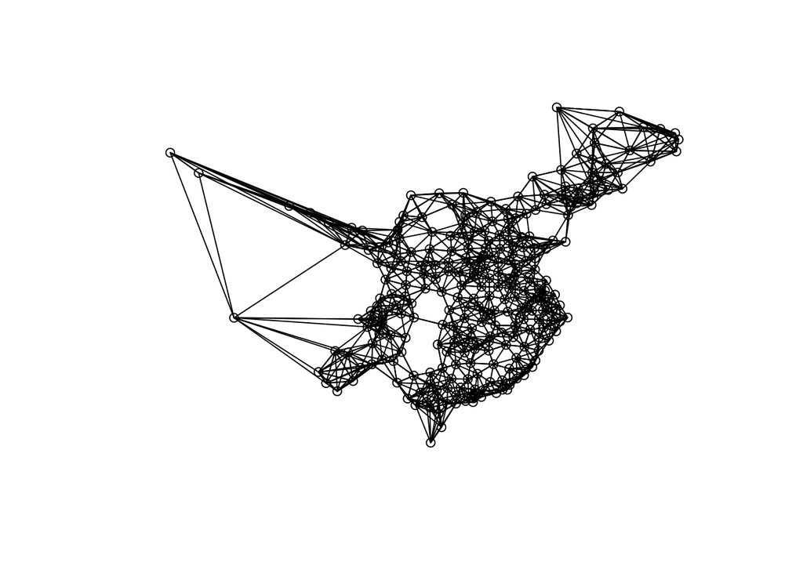

```r
## Identify coordinates of the centroid of the multipolygon
coords <- st_centroid(st_geometry(ct_spdata_wide))

## Create our 8 NN matrix
## Note that the latitude and longitude are handled using great circle distances
## R2 distances will be inaccurate
knn8W <- knearneigh(coords, k = 8)

## Convert our knn object to neighborhood list
list8nn <- knn2nb(knn8W)
## Convert to a matrix object
matrix8nn <- spdep::nb2mat(list8nn)
## Convert our neighborhood list to an listw object
listw8nn <- spdep::nb2listw(list8nn)
## Plot the neighborhood relationships
plot(list8nn, coords)
```

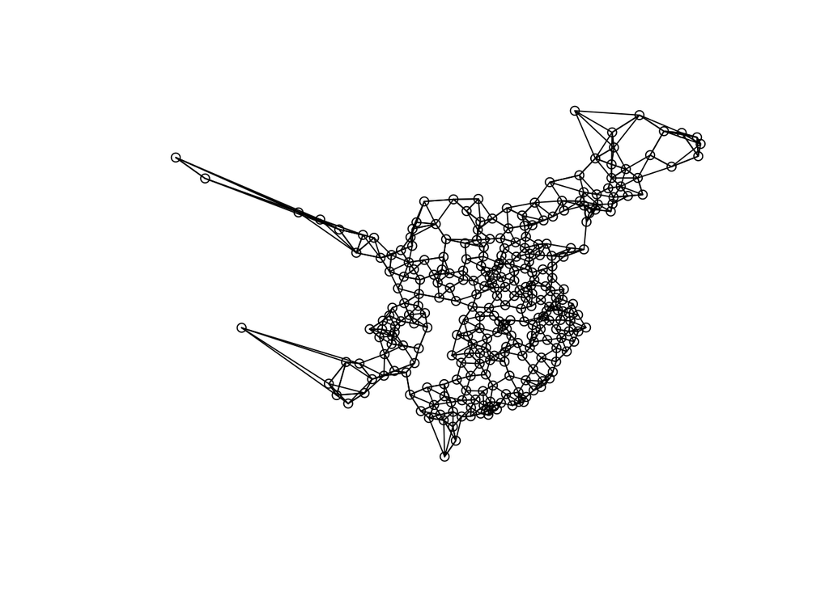

```r
## Identify coordinates of the centroid of the multipolygon
coords <- st_centroid(st_geometry(ct_spdata_wide))

## Create our 4 NN matrix
## Note that the latitude and longitude are handled using great circle distances
## R2 distances will be inaccurate
knn4W <- knearneigh(coords, k = 4)

## Convert our knn object to neighborhood list
list4nn <- knn2nb(knn4W)
## Convert to a matrix object
matrix4nn <- spdep::nb2mat(list4nn)
## Convert our neighborhood list to an listw object
listw4nn <- spdep::nb2listw(list4nn)
## Plot the neighborhood relationships
plot(list4nn, coords)
```

```r
## Create another weighting matrix based on contiguity relations (queen).
ct_spdata_wide %>% spdep::poly2nb("geometry") %>%
  spdep::nb2mat(zero.policy = TRUE) -> matrixWnb

ct_spdata_wide %>% spdep::poly2nb("geometry") %>%  spdep::nb2listw(zero.policy = TRUE) -> listwnb
```

Create spatial lagged variables.

```r
## Create spatial lag for some variables

lagGDPpc <- slag(ct_spdata_long$GDPpc, listw = listw4nn) %>% as.numeric( )

ct_spdata_long$lagGDPpc <- lagGDPpc

lagslry <- slag(ct_spdata_long$slry, listw = listw4nn) %>% as.numeric( )

ct_spdata_long$lagslry <- lagslry

lagtarl <- slag(ct_spdata_long$tarl, listw = listw4nn) %>% as.numeric( )

ct_spdata_long$lagtarl <- lagtarl

laghotel <- slag(ct_spdata_long$hotel, listw = listw4nn) %>% as.numeric( )

ct_spdata_long$laghotel <- laghotel

lagspot5A <- slag(ct_spdata_long$spot5A, listw = listw4nn) %>% as.numeric( )

ct_spdata_long$lagspot5A <- lagspot5A

lagterti<- slag(ct_spdata_long$terti, listw = listw4nn) %>% as.numeric( )

ct_spdata_long$lagterti <- lagterti
```

## Prepate data for MATLAB

```r
tlaged_logged_ct_spdata_long <- ct_spdata_long

## Use the independent variables from the previous year
for (i in 7:ncol(tlaged_logged_ct_spdata_long)) {
  tlaged_logged_ct_spdata_long[[i]] <- lag(tlaged_logged_ct_spdata_long[[i]], 1)
}
summary(tlaged_logged_ct_spdata_long)
```

```
##    城市shapefile      City                Lat             Long
##  三亚市   :   9   Length:2547        Min.   :18.26   Min.   : 84.9
##  三明市   :   9   Class :character   1st Qu.:27.83   1st Qu.:109.5
##  三门峡市 :   9   Mode  :character   Median :32.40   Median :114.3
##  上海|上海:   9                      Mean   :32.80   Mean   :113.9
##  上饶市   :   9                      3rd Qu.:37.52   3rd Qu.:118.5
##  东莞市   :   9                      Max.   :50.25   Max.   :131.2
##  (Other)  :2493
##           geometry         year               tarl
##  MULTIPOLYGON :2547   2011   :283   total       :4.217e+12
##  epsg:4326    :   0   2012   :283   between_id  :3.648e+12
##  +proj=long...:   0   2013   :283   between_time:2.817e+11
##                       2014   :283
##                       2015   :283
##                       2016   :283
##                       (Other):849
##            trev                    dmarl                    dmrev
##  total       :7.096e+12   total       :4.098e+12   total       :6.180e+12
##  between_id  :6.029e+12   between_id  :3.540e+12   between_id  :5.095e+12
##  between_time:4.920e+11   between_time:2.739e+11   between_time:4.687e+11
##
##
##
##
##           inarl                    inrev                    CPIpy
##  total       :2.926e+09   total       :1.224e+09   total       :1878.0
##  between_id  :2.883e+09   between_id  :1.184e+09   between_id  : 143.9
##  between_time:2.020e+06   between_time:2.221e+06   between_time:1300.7
##
##
##
##
##           CPI11                 hprice                  emphotel
##  total       :5.0462   total       :3.115e+10   total       :4065038
##  between_id  :0.3442   between_id  :2.603e+10   between_id  :3032891
##  between_time:4.5393   between_time:1.632e+09   between_time:   6213
##
##
##
##
```

[output cut: 49 more lines]

```
##  total       :5.293e+11   total       :3.635e+11   total       :1.184e+12
##  between_id  :4.071e+11   between_id  :5.865e+10   between_id  :8.266e+11
##  between_time:1.031e+11   between_time:2.984e+11   between_time:2.932e+11
##
##
##
##
##          laghotel              lagspot5A              lagterti
##  total       :1301190   total       :595.60   total       :98577
##  between_id  :1230239   between_id  :500.24   between_id  :34302
##  between_time:  13122   between_time: 42.75   between_time:57875
##
##
##
##
```

```r
## Drop all observations with missing values
tlaged_logged_ct_spdata_long <- na.omit(tlaged_logged_ct_spdata_long)

## Transfer all variables to log scale
tlaged_logged_ct_spdata_long <- tlaged_logged_ct_spdata_long %>%
  mutate(across(c(tarl:inrev, hprice:road, invest:lagspot5A), \(x) log(x+1)))

summary(tlaged_logged_ct_spdata_long)
```

```
##    城市shapefile      City                Lat             Long
##  三亚市   :   8   Length:2264        Min.   :18.26   Min.   : 84.9
##  三明市   :   8   Class :character   1st Qu.:27.83   1st Qu.:109.5
##  三门峡市 :   8   Mode  :character   Median :32.40   Median :114.3
##  上海|上海:   8                      Mean   :32.80   Mean   :113.9
##  上饶市   :   8                      3rd Qu.:37.52   3rd Qu.:118.5
##  东莞市   :   8                      Max.   :50.25   Max.   :131.2
##  (Other)  :2216
##           geometry         year          tarl             trev
##  MULTIPOLYGON :2264   2012   :283   Min.   : 6.830   Min.   : 6.134
##  epsg:4326    :   0   2013   :283   1st Qu.: 9.415   1st Qu.: 9.211
##  +proj=long...:   0   2014   :283   Median :10.022   Median : 9.914
##                       2015   :283   Mean   : 9.998   Mean   : 9.903
##                       2016   :283   3rd Qu.:10.654   3rd Qu.:10.643
##                       2017   :283   Max.   :13.300   Max.   :13.291
##                       (Other):566
##      dmarl            dmrev            inarl           inrev
##  Min.   : 6.830   Min.   : 5.168   Min.   :0.000   Min.   :0.001
##  1st Qu.: 9.401   1st Qu.: 9.199   1st Qu.:3.128   1st Qu.:2.169
##  Median :10.007   Median : 9.890   Median :4.347   Median :3.467
##  Mean   : 9.981   Mean   : 9.880   Mean   :4.333   Mean   :3.569
##  3rd Qu.:10.630   3rd Qu.:10.601   3rd Qu.:5.695   3rd Qu.:4.913
##  Max.   :13.294   Max.   :13.228   Max.   :9.408   Max.   :8.905
##
##      CPIpy            CPI11           hprice          emphotel
##  Min.   : 99.74   Min.   :1.000   Min.   : 7.457   Min.   :0.0373
##  1st Qu.:101.20   1st Qu.:1.033   1st Qu.: 8.133   1st Qu.:0.9626
##  Median :101.80   Median :1.077   Median : 8.331   Median :1.4781
##  Mean   :101.67   Mean   :1.075   Mean   : 8.426   Mean   :1.6905
##  3rd Qu.:102.30   3rd Qu.:1.112   3rd Qu.: 8.628   3rd Qu.:2.1282
##  Max.   :106.10   Max.   :1.198   Max.   :10.923   Max.   :6.4727
##
##      GDPpc             slry             pop              area
##  Min.   : 8.773   Min.   : 9.753   Min.   : 5.456   Min.   : 7.016
##  1st Qu.:10.269   1st Qu.:10.619   1st Qu.: 7.774   1st Qu.: 8.938
##  Median :10.636   Median :10.828   Median : 8.179   Median : 9.403
##  Mean   :10.648   Mean   :10.825   Mean   : 8.177   Mean   : 9.358
##  3rd Qu.:11.010   3rd Qu.:11.026   3rd Qu.: 8.635   3rd Qu.: 9.849
##  Max.   :12.281   Max.   :11.917   Max.   :10.362   Max.   :12.443
##
```

[output cut: 25 more lines]

```
##  Min.   :2.643   Min.   : 0.000   Min.   : 9.772   Min.   :10.18
##  1st Qu.:6.502   1st Qu.: 7.624   1st Qu.:10.550   1st Qu.:10.65
##  Median :6.769   Median : 7.923   Median :10.760   Median :10.84
##  Mean   :6.807   Mean   : 7.962   Mean   :10.757   Mean   :10.84
##  3rd Qu.:7.053   3rd Qu.: 8.326   3rd Qu.:10.968   3rd Qu.:11.03
##  Max.   :8.757   Max.   :12.329   Max.   :11.621   Max.   :11.52
##
##     lagtarl          laghotel       lagspot5A         lagterti
##  Min.   : 8.462   Min.   :2.526   Min.   :0.0000   Min.   :25.59
##  1st Qu.: 9.899   1st Qu.:3.384   1st Qu.:0.2231   1st Qu.:35.71
##  Median :10.284   Median :3.663   Median :0.4055   Median :40.07
##  Mean   :10.293   Mean   :3.678   Mean   :0.4310   Mean   :40.60
##  3rd Qu.:10.677   3rd Qu.:3.927   3rd Qu.:0.6931   3rd Qu.:45.24
##  Max.   :12.227   Max.   :5.324   Max.   :1.4469   Max.   :67.19
##
```